# Prediction Project Write-up report

*Summary*

*Background*

The data from the area of Human Activity Recognition, provided consists six young health participants were asked to perform exercise repetitively. This consists of one set of 10 repetitions of the Unilateral Dumbbell Biceps Curl in five different fashions: exactly according to the specification (Class A), throwing the elbows to the front (Class B), lifting the dumbbell only halfway (Class C), lowering the dumbbell only halfway (Class D) and throwing the hips to the front (Class E).The details of the project is provided here http://groupware.les.inf.puc-rio.br/har.

*Details on Model development and application*

In the following section I have discussed the different steps along with scripts and outputs.

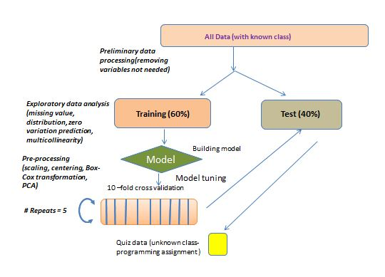

Note: Execution of some of chucks is disabled that need long time to run. Output of such chucks is provided please feel free run such chucks, if needed. Also results of some of just pipeline chunks is hidden.

**Preliminaries**

- **Reading the data**

```r
setwd("C:/Users/umesh.rosyara/Documents/GitHub/mlc/data")
humactivity <- read.csv("pml-training.csv", head = TRUE)
summary(humactivity)
```

- **Preliminary Processing of data**

Some columns with partial information such as mean variance, skewness was removed. Also other variables were checked for completeness.

```r
humactivity1 <- humactivity[,c(-1:-7, -12:-36, -50:-59, -69:-83, -87:-101,
                               -103:-112, -125:-139, -141:-150)]
# check the proportion of missing values
mising.out <- rep(NA, length(humactivity1))
for (i in 1:ncol (humactivity1)-1){
mising.out[i] <- as.numeric ( table (!is.na(humactivity1[,i]))["TRUE"]) /length(humactivity1[,i])
}
```

There were no missing values in the predictor variables. Similarly we check the `classe` variable. None of value in the `classe` variable were missing.

```r
table (is.na (humactivity1$classe))
```

```
##
## FALSE
## 19622
```

**Splitting of data**

I decided to split data in 60% training set and 40% test set. The training set only be used for training of model, resampling and cross validation. The split was intentional made provided the size of data set and effect prediction of out of sample prediction. The analysis were done using the package `caret`.

```r
require(caret)
set.seed(1234) # adding the seed to make it reproducible split
inTrain <- createDataPartition(y = humactivity1$classe, p = 0.6, list = FALSE)
training <- humactivity1[ inTrain,]
testing <- humactivity1[-inTrain,]
# Proportion of training set
round (nrow(training)/nrow(humactivity1),2)

# Proportion in testing set
round (nrow(testing)/nrow(humactivity1),2)
```

**Exploratory analysis of the training data**

Before deciding the covariates to use all potential covariates were examined by visualizing their distribution. No formal normality test was useful due to large dataset.

- **Plotting distribution using histogram**

```r
# the following code works for windows R-GUI
# plot new window works differently in other interface.
# for example R studio graphic device do not allow multiple device using
# dev.new function
for (i in 0:2){
j = i*20 + 1; k = j + 19
if(k > 52){
  k = 52  }
# develop new plot with specify size
dev.new(width=24, height=15)
par(mfrow = c(5,4))
for (i in j:k){
par (mar=c(4.1,1.1,1.1,1.1))
#bottom, left, top and right margins
x <- training[,i]
pt <- hist(x, col = i, prob=TRUE, main = NULL, xlab = paste(i, "-", names(training)[i], sep = ""))
} }
```

- **Near zero variation test**

Another important things to check if any variable has near zero variation.

```r
# near zero variation
nzv <- nearZeroVar(training, saveMetrics = TRUE)
print(nzv)
```

- **Identifying correlated variables**

The model I will trying are either neutral to correlated predictors or are benefited by uncorrelated variables. In any case more variables need higher computation time. So I decided to get rid of the correlated variables. A cut-off of 0.9 was set. As a result of removing highly correlated variables only 45 variables were left.

```r
descrCor <- cor(training[,-53])
highCorr <- sum(abs(descrCor[upper.tri(descrCor)]) > 0.90)
print(highCorr)
```

```
[1] 11
```

```r
highlyCorDescr <- findCorrelation(descrCor, cutoff = 0.90)
print(length (highlyCorDescr))
```

```
[1] 7
```

```r
trainingFld <- training[, -highlyCorDescr]
testingFld <- testing[,-highlyCorDescr]
```

- **Analysis of variation**

```r
# variables with significant group effect on: using anova
log10p <- rep (NA, length(trainingFld)-1)
for (i in 1: 45){
trainingFld1 <- as.matrix (trainingFld[,-46])
group <- trainingFld[,46]
out1 <- anova(lm( trainingFld1[,i] ~ group))
log10p[i] <- -log10(out1$ `Pr(>F)`[1])
}
non.sig <- which (log10p < 3)
print(non.sig)
trainingFldSig <- trainingFld[, -non.sig]
testingFldSig <- testingFld[-non.sig]
```

```
[1]  4  5  6 14 15 27 39 42
```

- **Distribution over class: overlayed density plots**

To check if overlayed density plots can provide any clue about usefulness of any variable involved.

```r
key_colors <- c("black","green","red","blue", "pink")
acc_par <- list(superpose.line = list(col = key_colors), lwd=1.5, lty=1.5, alpha = 0.3)
for (i in 0:1){
j = i*20 + 1
k = j + 19
if(k > 37){
  k = 37
  }
dev.new(width=24, height=15)
plt <- featurePlot(x = trainingFldSig[, j:k], y = trainingFldSig$classe,
plot = "density",
par.settings=acc_par,
scales = list(x = list(relation="free"),
y = list(relation="free")),adjust = 1.5, pch = "|", layout = c(5, 4),
auto.key = list(columns = 3, col = key_colors, lines=TRUE))
print(plt)
}
```

After observing the distributions, the overall impression was it is difficult to find few variable that can explain fully with losing information. So decided to go for all 37 variables for the momonent. The PC analysis can help reduce dimention and scability, however the outlier present in the data clearly present empediment.

- **Linear Dependencies**

Before stepping in training of the model stage, checking whether any of variables show linear dependencies with other was tested.

```r
comboInfo <- findLinearCombos(trainingFldSig)
print(comboInfo)
```

**Training of the model**

**Training control parameters**

Considering the dataset, initially 10-fold cross validation repeated 5 times was done. This has been frequently used in other literatures and seems perform well in our situation as well see the results below.  
The first step to make results reproducible list with seed was created and stored.

```r
# seeds to make consistent seeds
# target is 10 fold cross validation with 5 repetition
set.seed(123)
seeds <- vector(mode = "list", length = 51)
for(i in 1:50) seeds[[i]] <- sample.int(1000, 22)
seeds[[51]] <- sample.int(1000,1)
print(seeds)
```

```r
tc <- trainControl("repeatedcv", number=10, repeats=5, seed=seeds, classProbs=TRUE, savePred=T)
```

**Preprocessing of the data**

As part of each function, normalizing data, centering and scaling was done with arguments `preProc=c("BoxCox", "center", "scale")` in caret package `training` function. The transformation was done as the variables show moderate to severe deviation from normal distribution. The standardizing of the variables was done. In some cases principle component analysis was done to reduce dimensionality of data and reducing computation time.

**Machine learning algorithm choice**

First of most simple models was run using all variables. The following is codes (not running mode as some of them may take long time execute), summary of results on accuracy for different algorithms:

```r
# linear discriminant analysis
ldaFit <- train(classe ~., data=trainingFldSig, method= "lda", trControl=tc, preProc=c("BoxCox", "center", "scale"))
plsfittesting <- predict(ldaFit, newdata=testing)
confusionMatrix(data=plsfittesting, testing$classe)

#method= "qda"
qdaFit <- train(classe ~., data=trainingFldSig, method= "qda", trControl=tc, preProc=c("BoxCox", "center", "scale"))
qdafittesting <- predict(qdaFit, newdata=testing)
confusionMatrix(data=qdafittesting, testing$classe)

#k-Nearest Neighbors
knnFit <- train(classe ~., data=trainingFldSig, method= "knn", trControl=tc, preProc=c("BoxCox", "center", "scale"))
knnfittesting <- predict(knnFit, newdata=testing)
confusionMatrix(data=knnfittesting, testing$classe)

#k-Nearest Neighbors, with pca
preProc <- preProcess(trainingFldSig[,-38], method = c("BoxCox","pca"), thresh = 0.8)
trainPC <- predict(preProc, trainingFldSig[,-38])
knnFit <- train(trainingFldSig$classe ~., data=trainPC, method= "knn", trControl=tc)
knnfittesting <- predict(preProc, testingFldSig[,-38])
confusionMatrix( testing$classe, predict(knnFit, knnfittesting ))


# method = 'bstTree'
boostTFit <- train(classe ~., data=trainingFldSig, method= "bstTree", trControl=tc, preProc=c("BoxCox", "center", "scale"))
boostTfittesting <- predict(boostTFit, newdata=testing)
confusionMatrix(data=boostTfittesting, testing$classe)
# interestingly this method did poor in discrimination of  classe A and B but fairly well for others

# Tree bagging method
bagFit <- train(classe ~., data=trainingFldSig, method= "treebag", trControl=tc, preProc=c("BoxCox", "center", "scale"))
bagfittesting <- predict(bagFit, newdata=testing)
confusionMatrix(data=bagfittesting, testing$classe)

#Random forest , "rf", with pca
preProc <- preProcess(trainingFldSig[,-38], method = c("BoxCox","pca"), thresh = 0.8)
trainPC <- predict(preProc, trainingFldSig[,-38])
rfFit <- train(trainingFldSig$classe ~., data=trainPC, method= "rf", trControl=tc)
rffittesting <- predict(preProc, testingFldSig[,-38])
confusionMatrix( testing$classe, predict(rfFit, rffittesting ))
```

In the above listed method K-Nearest neighbor provides higher accuracy and time required to implement is fairly fast. The method as Tree bagging provides greater accuracy than K-Nearest Neighbor method. However the highest accuracy was achieved using random forest (my choice) - however the time required to complete is very high. The following is results and script.

```r
rfFit <- train(classe ~., data=trainingFldSig, method=  "rf", trControl=tc, preProc=c("BoxCox", "center", "scale"))
rffittesting <- predict(rfFit, newdata=testing)
confusionMatrix(data=rffittesting, testing$classe)
```

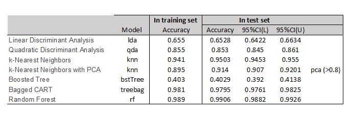

Based on the 37 pedictors and 11776 samples, the following was the accuracy in cross validation (10 fold, repeated 5 times).

```
mtry  Accuracy  Kappa  Accuracy SD  Kappa SD
2     0.987     0.984  0.00286      0.00361
19    0.989     0.986  0.00321      0.00407
37    0.983     0.979  0.00362      0.00459
```

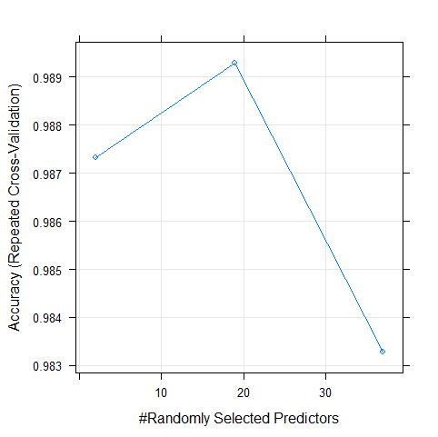

Accuracy was used to select the optimal model using the largest value. The final value used for the model was mtry = 19. The following is confusion matrix.

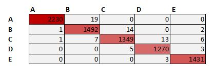

The following are overall accuracy stastics was 0.9906 with 95% confidence interval being 0.9882 - 0.9926 in testing set. The kappa stastic was 0.9881. The following is summary statistics by class:

```
                        Class: A Class: B Class: C Class: D Class: E
  Sensitivity            0.9991   0.9829   0.9861   0.9876   0.9924
  Specificity            0.9966   0.9973   0.9958   0.9988   0.9995
  Pos Pred Value         0.9916   0.9887   0.9804   0.9937   0.9979
  Neg Pred Value         0.9996   0.9959   0.9971   0.9976   0.9983
  Prevalence             0.2845   0.1935   0.1744   0.1639   0.1838
  Detection Rate         0.2842   0.1902   0.1719   0.1619   0.1824
  Detection Prevalence   0.2866   0.1923   0.1754   0.1629   0.1828
  Balanced Accuracy      0.9979   0.9901   0.9910   0.9932   0.9960
```

**Conclusion**

In conclusion `rf` model based on 37 predictors provides very high accuracy of prediction in this dataset with expectation of 1% of out of sample error rate, however running the model required substential time.K-nearest neigbhbor is alternative with ~5% out of sample error rate although with significantly less time required to perform compuation can be an alternative.